# Geospatial Analysis Workshop

The goal is to introduce you to the Python tools to do basic spatial analysis without the need to open up 3rd party GIS software (Esri ArcGIS, QGIS, etc.). This is done using the following libraries:

1. Fiona (for file I/O)
2. Shapely (for geometric operations)
3. Rtree (for spatial indexing)
4. Geopandas (for data wrangling using pandas-like dataframes and built upon the previous three modules among others)

`Fiona` is concerned exclusively with vector data. It is a Python wrapper for vector data access functions from the OGR library.  
`Shapely` is a Python module for set-theoretic analysis and manipulation of planar features using functions from the well known and widely deployed GEOS library.

To test if you have installed all the main modules for this workshop, simply do a quick import test

```python
import fiona
import shapely
import rtree
import geopandas
```

There are some additional non-standard modules we will be using. You can install them now using `pip install` in your terminal or as we go along.

```python
import geocoder
import more_itertools # you can also use "conda install more-itertools"
import geojson
import simplekml
```

## Workshop Topics

Here are the topics we'll be covering in this workshop.  
A. Geocoding  
B. Spatial Analysis

1. Point-in-Polygon
2. Nearest line to a given point
3. Line intersecting polygon
4. Find all points within a specified distance
5. Voronoi Diagram

## Geocoding

To access the Google Maps Geocoding API directly, we need the `requests` library.

```python
import requests
```

You also need a Google Maps Geocoding API key. I'm sharing mine with you. BTW, it's good practice never to never share your API key :)

```python
apikey = 'AIzaSyDkupbsW4HxA38Jl9Ax2L2PqUhh5sUu1Hc'
params = {'address': 'Ann Arbor, MI', 'id':apikey}
```

Use `requests` to send a `get` request to the API

```python
url = 'https://maps.googleapis.com/maps/api/geocode/json'
r = requests.get(url, params=params)
results = r.json()['results']
results
```

```
[{'address_components': [{'long_name': 'Ann Arbor',
    'short_name': 'Ann Arbor',
    'types': ['locality', 'political']},
   {'long_name': 'Washtenaw County',
    'short_name': 'Washtenaw County',
    'types': ['administrative_area_level_2', 'political']},
   {'long_name': 'Michigan',
    'short_name': 'MI',
    'types': ['administrative_area_level_1', 'political']},
   {'long_name': 'United States',
    'short_name': 'US',
    'types': ['country', 'political']}],
  'formatted_address': 'Ann Arbor, MI, USA',
  'geometry': {'bounds': {'northeast': {'lat': 42.3239729, 'lng': -83.6758069},
    'southwest': {'lat': 42.222668, 'lng': -83.79957209999999}},
   'location': {'lat': 42.2808256, 'lng': -83.7430378},
   'location_type': 'APPROXIMATE',
   'viewport': {'northeast': {'lat': 42.3239729, 'lng': -83.6758069},
    'southwest': {'lat': 42.222668, 'lng': -83.79957209999999}}},
  'place_id': 'ChIJMx9D1A2wPIgR4rXIhkb5Cds',
  'types': ['locality', 'political']}]
```

The API returns back a list of dictionaries with embedded lists of dictionaries, etc

To access the longitude and latitude coordinates

```python
location = results[0]['geometry']['location']
location['lng'], location['lat']
```

```
(-83.7430378, 42.2808256)
```

Some people think this is too labyrinth to deal with and that it should be simpler.

Fortunately, there are a lot of Python geocoding modules available to abstract away a lot of the programming details (but not the data). A simple one to use, in my opinion, is `geocoder`.

```python
import geocoder as gc
```

To use the Google Maps Geocoding API through `geocoder`

```python
aa = gc.google('Ann Arbor, MI')
```

**Note**: no API key was necessary using the geocoder module. Not sure why that is, maybe the module is using their own API key internally.

The geocoder returns back the response available in different standard formats.

```python
aa.geojson
```

```
{'bbox': [-83.79957209999999, 42.222668, -83.6758069, 42.3239729],
 'geometry': {'coordinates': [-83.7430378, 42.2808256], 'type': 'Point'},
 'properties': {'accuracy': 'APPROXIMATE',
  'address': 'Ann Arbor, MI, USA',
  'bbox': [-83.79957209999999, 42.222668, -83.6758069, 42.3239729],
  'city': 'Ann Arbor',
  'confidence': 3,
  'country': 'US',
  'county': 'Washtenaw County',
  'encoding': 'utf-8',
  'lat': 42.2808256,
  'lng': -83.7430378,
  'location': 'Ann Arbor, MI',
  'ok': True,
  'place': 'ChIJMx9D1A2wPIgR4rXIhkb5Cds',
  'provider': 'google',
  'quality': 'locality',
  'state': 'MI',
  'status': 'OK',
  'status_code': 200},
 'type': 'Feature'}
```

```python
aa.json
```

```
{'accuracy': 'APPROXIMATE',
 'address': 'Ann Arbor, MI, USA',
 'bbox': [-83.79957209999999, 42.222668, -83.6758069, 42.3239729],
 'city': 'Ann Arbor',
 'confidence': 3,
 'country': 'US',
 'county': 'Washtenaw County',
 'encoding': 'utf-8',
 'lat': 42.2808256,
 'lng': -83.7430378,
 'location': 'Ann Arbor, MI',
 'ok': True,
 'place': 'ChIJMx9D1A2wPIgR4rXIhkb5Cds',
 'provider': 'google',
 'quality': 'locality',
 'state': 'MI',
 'status': 'OK',
 'status_code': 200}
```

```python
aa.wkt
```

```
'POINT(-83.7430378 42.2808256)'
```

```python
aa.osm
```

```
{'addr:city': 'Ann Arbor',
 'addr:country': 'US',
 'addr:state': 'MI',
 'x': -83.7430378,
 'y': 42.2808256}
```

To get the longitude and latitude, we don't need to traverse any of the formats. Just use the `latlng` attribute.

```python
aa.latlng
```

```
[42.2808256, -83.7430378]
```

### Reverse Geocoding

Input a GPS coordinate to get back an address and other information

```python
b = gc.google([42.2777, -83.7426], method='reverse')
b.address
```

```
'512 E William St, Ann Arbor, MI 48104, USA'
```

```python
b.geojson
```

```
{'bbox': [-83.7427919, 42.2775348, -83.74253879999999, 42.2777308],
 'geometry': {'coordinates': [-83.7426653, 42.2776328], 'type': 'Point'},
 'properties': {'accuracy': 'ROOFTOP',
  'address': '512 E William St, Ann Arbor, MI 48104, USA',
  'bbox': [-83.7427919, 42.2775348, -83.74253879999999, 42.2777308],
  'city': 'Ann Arbor',
  'confidence': 10,
  'country': 'US',
  'county': 'Washtenaw County',
  'encoding': 'utf-8',
  'housenumber': '512',
  'lat': 42.2776328,
  'lng': -83.7426653,
  'location': '42.2777, -83.7426',
  'ok': True,
  'place': 'ChIJ4w67NT-uPIgRYnuoPE_1CTY',
  'postal': '48104',
  'provider': 'google',
  'quality': 'premise',
  'state': 'MI',
  'status': 'OK',
  'status_code': 200,
  'street': 'E William St'},
 'type': 'Feature'}
```

### Geocoding of other inputs

```python
ip = gc.ip('me')
ip.latlng
```

```
[42.3241, -83.7113]
```

```python
ip = gc.ip('141.211.189.160')
ip.address
```

```
'Ann Arbor, Michigan, US'
```

You cannot search by name though. That's a different Google API.

```python
r = gc.google('Original Cottage Inn Pizza')
r.latlng
```

```
[]
```

### Caveats

Different geocoding providers will provide back different coordinates. Let's use the Original Cottage Inn as common ground.

**Google**

```python
goog = gc.google("512 E William St Ann Arbor MI")
goog.latlng
```

```
[42.2776328, -83.7426653]
```

**ESRI**

```python
esri = gc.arcgis("512 E William St Ann Arbor MI")
esri.latlng
```

```
[42.27779225840709, -83.74267018158281]
```

**Open Street Maps**

```python
osm = gc.osm("512 E William St Ann Arbor MI")
osm.latlng
```

```
[42.2777438, -83.7425441]
```

**Mapbox**

You'll also need an API key to use Mapbox services. I'm not willing to share this one.

```python
import os
if True:
    mapbox_apikey = os.getenv('MAPBOX_ACCESS_TOKEN')
    mb = gc.mapbox("512 E William St Ann Arbor MI", access_token=apikey)
```

```python
mb.latlng
```

```
[42.277632, -83.74264]
```

So what does all these different results from providers mean? It's probably best to use the geocoding service provider that coincides with your basemap.

Now that we know how to turn addresses into spatial data (e.g. csv file of latitutde and longitude), let's move onto some basic spatial analysis.

# Spatial Analysis

## Example 1: Point-in-Polygon

### Find the census block group associated with each deer crash downloaded from Michigan Traffic Crash Facts

This involves performing a spatial join. These are the steps we will take.

1. Read in shapefile and csv file of lon/lat
2. Create spatial index from bbox of polygons (optional)
3. Do lookup of intersecting bbox of points and polygons (optional)
4. Check for point-in-polygon
5. Create new shapefile

Let's import the modules we will need.

```python
from shapely.geometry import shape, Point
import fiona
import pandas as pd
import time
```

This is for formatting purposes when displaying pandas dataframe.

```python
pd.options.display.max_rows = 10
```

### Data

Michigan Census Block shapefile can be found at http://gis.michigan.opendata.arcgis.com/  
Deer crash data can be found at https://www.michigantrafficcrashfacts.org/

```python
census_blocks_shp = r'2010_Block_Groups.shp'
deer_csv = r'deer_crashes.txt'
```

### Step 1

We will open the shapefile using `fiona`. We will read in the csv using `pandas`.

```python
blockgroups = fiona.open(census_blocks_shp,'r')
deer = pd.read_csv(deer_csv, sep='\t', header=0)
```

Filter the csv for only points within Michigan. Create a list of GPS coordinates.

```python
deer = deer[(deer['Crash Latitude'] > 41) & (deer['Crash Latitude'] < 49)]
deer.reset_index(inplace=True)
gps = list(zip(deer['Crash Longitude'],deer['Crash Latitude']))
```

### Step 4 (without a spatial index)

We'll use a nested `for` loop. The outer loop will be the points. The inner loop will be the polygons. For each GPS coordinate:  
A. Construct a shapely `Point` from the coordinates  
B. Loop through each polygon  
C. Construct a shapely `Polygon` from the shapefile  
D. Check for point-in-polygon  
E. `append` to a list of matches

```python
t0 = time.time()
join1 = []
n = 0
for i, xy in enumerate(gps):
    pt = Point(xy)
    for j, blockgroup in enumerate(blockgroups):
        polygon = shape(blockgroup['geometry'])
        if pt.within(polygon):
            join1.append((i,j))
            break # this line is very important for efficiency
    n += j+1
t1 = time.time()
print('Point in Polygon {:.1f}s'.format(t1-t0))
print('Withins per second {:.0f}'.format(n/(t1-t0)))
```

```
Point in Polygon 146.7s
Withins per second 1680
```

```python
8167*89
```

```
726863
```

### Step 2

`rtree` is a Python library for spatially indexing kD bounding box data (based on libspatialindex, a C++ library)

To construct a spatial index, we iterate through the polygons and insert the bounding box into the spatial index.

```python
from rtree import index

t2 = time.time()
idx = index.Index()
for j, blockgroup in enumerate(blockgroups):
    idx.insert(j, shape(blockgroup['geometry']).bounds)
t3 = time.time()
print('Creating R-tree spatial index {:.1f}s'.format(t3-t2))
```

```
Creating R-tree spatial index 5.3s
```

### Step 3 and Step 4 (with a spatial index)

We'll use a nested `for` loop. The outer loop will be the points. The inner loop will be the candidate polygons. For each GPS coordinate:  
A. Construct a shapely `Point` from the coordinates  
B. Find intersecting bounding boxes from spatial index and the point  
C. Construct a shapely `Polygon` from the shapefile  
D. Check for point-in-polygon among candidate polygons  
E. `append` a list of matches

```python
t3 = time.time()
join2 = []
n = 0
for i, xy in enumerate(gps):
    pt = Point(xy)
    # check for bounding box intersection
    candidates = idx.intersection(pt.coords[0])
    # check for actual intersection among candidates
    for k, j in enumerate(candidates):
        polygon = shape(blockgroups[j]['geometry'])
        if pt.within(polygon):
            join2.append((i,j))
            break
    n += k+1
t4 = time.time()
print('Point in Polygon with R-tree {:.1f}s'.format(t4-t3))
print('Withins per second {:.0f}'.format(n/(t4-t3)))
```

```
Point in Polygon with R-tree 0.2s
Withins per second 622
```

```python
n
```

```
128
```

Let's do a sanity check. Let's compare our lists to make sure they are identical (ignoring duplicates which there shouldn't be).

```python
print(set(join1) == set(join2))
```

```
True
```

In this case, using a spatial index is more efficient due to the specifics of our problem and data.

## Visualization of the R-tree Bounding Boxes

Leaves of the R-tree spatial index

[figure not shown]

### Step 5

Now that we performed the spatial join, let's write back the results to a new shapefile.  
A. Copy the coordinate reference system and schema from the shapefile  
B. Create a new schema  
C. Create a dictionary from our list of matches  
D. Write a new shapefile using `fiona`

Import necessary modules

```python
import collections
from shapely.geometry import mapping
```

Create schema

```python
crs = blockgroups.crs
schema = blockgroups.schema

# Use OrderedDict if you care about the order of columns in your shapefile
prop = collections.OrderedDict()
prop['Crash Instance'] = 'int'
prop['Longitude'] = 'float'
prop['Latitude'] = 'float'
for key in schema['properties']:
    prop[key] = schema['properties'][key]

newschema = {'geometry':'Point',
             'properties':prop}
```

Create dictionary that contains spatial join information

```python
newschema
```

```
{'geometry': 'Point',
 'properties': OrderedDict([('Crash Instance', 'int'),
              ('Longitude', 'float'),
              ('Latitude', 'float'),
              ('OBJECTID', 'int:10'),
              ('NAME', 'str:80'),
              ('LABEL', 'str:80'),
              ('TYPE', 'str:80'),
              ('LINK', 'str:80'),
              ('CNTY_CODE', 'str:80'),
              ('SQKM', 'float:24.15'),
              ('SQMILES', 'float:24.15'),
              ('ACRES', 'float:24.15'),
              ('VER', 'str:80'),
              ('LAYOUT', 'str:80'),
              ('PENINSULA', 'str:80'),
              ('ShapeSTAre', 'float:24.15'),
              ('ShapeSTLen', 'float:24.15')])}
```

```python
polylookup = dict(join2)
```

Create new shapefile

```python
with fiona.open('brandnew.shp','w',crs=crs,driver='ESRI Shapefile',schema=newschema) as fout:
    for i, xy in enumerate(gps):
        point = Point(xy)
        ppty = {'Crash Instance':int(deer.at[i,'Crash Instance']),
                'Longitude':xy[0],
                'Latitude':xy[1]}
        for key in blockgroups[polylookup[i]]['properties']:
            ppty[key] = blockgroups[polylookup[i]]['properties'][key]
        fout.write({'geometry':mapping(point),'properties':ppty})
```

## Geopandas Approach to Point-in-Polygon

`geopandas` can also perform point-in-polygon calculations. The approach is much simpler since it automatically creates a spatial index when you read in the shapefile. It's also more beneficial if you are familiar with the `pandas` library and syntax.

```python
import geopandas as gp
```

```python
%%time
blockgroups = gp.read_file(census_blocks_shp)
deer = pd.read_csv(deer_csv, sep='\t', header=0)

# construct shapely Point
deer['geometry'] = deer.apply(lambda df: Point(df['Crash Longitude'],df['Crash Latitude']), axis=1)
# convert pandas DataFrame to geopandas GeoDataFrame
deer = gp.GeoDataFrame(deer)

deer.crs = blockgroups.crs # next line will complain sometimes without this line
deerblockgroups = gp.sjoin(deer, blockgroups, how='left', op='within')

deerblockgroups.to_file('newshapefile.shp')
```

```
Wall time: 5.3 s
```

**Note**: Most of the computational time is spent reading in the shapefile (and implicitly constructing the spatial index for you).

```python
pd.options.display.max_rows = 6
deerblockgroups
```

|  | Crash Instance | Crash Longitude | Crash Latitude | Crash Report | geometry | index_right | ACRES | CNTY_CODE | LABEL | LAYOUT | LINK | NAME | OBJECTID | PENINSULA | SQKM | SQMILES | ShapeSTAre | ShapeSTLen | TYPE | VER |
| --- | --- | --- | --- | --- | --- | --- | --- | --- | --- | --- | --- | --- | --- | --- | --- | --- | --- | --- | --- | --- |
| 0 | 201510 | -87.641171 | 45.326045 | UD-10 | POINT (-87.64117096142701 45.326045362139) | 3813.0 | 23401.652 | 109 | BG 2 | portrait | 1099604002 | 9604002 | 3814.0 | upper | 94.704 | 36.565 | 9.470415e+07 | 52320.496433 | BG | 16a |
| 1 | 201511 | -87.688674 | 45.151651 | UD-10 | POINT (-87.68867367367901 45.151650694129) | 3814.0 | 18991.544 | 109 | BG 3 | portrait | 1099604003 | 9604003 | 3815.0 | upper | 76.857 | 29.674 | 7.685688e+07 | 58549.681816 | BG | 16a |
| 2 | 2015119 | -86.207317 | 42.812027 | UD-10 | POINT (-86.207317209574 42.812026835783) | 5396.0 | 803.269 | 139 | BG 2 | portrait | 1390221032 | 0221032 | 5397.0 | lower | 3.251 | 1.255 | 3.250748e+06 | 9687.438446 | BG | 16a |
| ... | ... | ... | ... | ... | ... | ... | ... | ... | ... | ... | ... | ... | ... | ... | ... | ... | ... | ... | ... | ... |
| 87 | 2015845 | -84.686677 | 43.394956 | UD-10 | POINT (-84.68667720494001 43.39495577284099) | 1483.0 | 17006.293 | 057 | BG 1 | portrait | 0570002001 | 0002001 | 1484.0 | lower | 68.823 | 26.572 | 6.882277e+07 | 40070.574528 | BG | 16a |
| 88 | 2015846 | -84.618478 | 43.388739 | UD-10 | POINT (-84.618478328336 43.388739158957) | 1496.0 | 32043.176 | 057 | BG 3 | landscape | 0570002003 | 0002003 | 1497.0 | lower | 129.676 | 50.068 | 1.296755e+08 | 53989.609735 | BG | 16a |
| 89 | 20159 | -87.303158 | 45.764572 | UD-10 | POINT (-87.30315758892401 45.764572394044) | 867.0 | 32413.260 | 041 | BG 2 | portrait | 0419707002 | 9707002 | 868.0 | upper | 131.173 | 50.646 | 1.311732e+08 | 66919.690565 | BG | 16a |

90 rows × 20 columns

## Example 2: Find Nearest Line to a Point

### What road am I on given a GPS coordinate?

1. Read in shapefile and csv of lat/lon
2. Create spatial index from bbox of lines
3. Do lookup of intersecting bbox of points and lines
4. Calculate distance from chosen lines to point
5. Save to new shapefile

Read in the files that we will be using

```python
gps_csv = r'gpslogger.txt'
roads_shp = r'All_Roads.shp'
```

### Step 1

```python
roads = fiona.open(roads_shp,'r')
trip = pd.read_csv(gps_csv, header=None)
trip.columns = ['Lat','Lon']
```

I know the trip data was collected at a sampling rate of 10Hz. It's probably a safe assumption that vehicles won't change roads every 0.1s. I'll resample the data for every 1 second.

```python
trip = trip[::10]
trip.shape
```

```
(2110, 2)
```

There are at least two methods to create a spatial index using R-tree.

### Step 2 (Part A: Single Insert)

Same as before

```python
t0 = time.time()
idx = index.Index()
for j, obj in enumerate(roads):
    idx.insert(j, shape(obj['geometry']).bounds)
t1 = time.time()
print('Creating spatial index using single insert method {:.1f}s'.format(t1-t0))
```

```
Creating spatial index using single insert method 227.5s
```

### Step 2 (Part B: Bulk Insert)

Another option is a bulk insert. This pre-sorts the data before constructing the spatial index. The previous method constructs the spatial index after every insert.

*Bulk insert* requires creating a generator function. You also need to pass a third argument of `None` (which we ignored in the previous case).

```python
t2 = time.time()

# generator function
def line_generator():
    for j, obj in enumerate(roads):
        yield (j, shape(obj['geometry']).bounds, None)

bulk_idx = index.Index(line_generator())
t3 = time.time()
print('Creating spatial index using bulk insert method {:.1f}s'.format(t3-t2))
```

```
Creating spatial index using bulk insert method 142.8s
```

Once created using this method, the spatial index performs exactly the same way.

### Step 3 and 4

Additional module needed for this step

```python
import numpy as np
```

Initialize some variables

```python
rs = []
count = 0
nn = 3
nnrank = []
```

We'll use a nested `for` loop. The outer loop will be the points. The inner loop will be the polygons. For each GPS coordinate:  
A. Create a `zip` iterator for the coordinates  
B. Construct a shapely `Point` from the coordinates  
C. Find the nearest `nn` neighbors to the shapely `Point`  
D. Loop through each neighbor and calculate the distance to the shapely `Point`  
E. Find the minimum distance and `append` to the list of road segments

```python
t3 = time.time()
gps = zip(trip['Lon'],trip['Lat']) # one use only
for i, xy in enumerate(gps):
    pt = Point(xy)
    rid = bulk_idx.nearest(pt.coords[0], nn)
    d, RID = [], []
    for k, id in enumerate(rid):
        line = shape(roads[id]['geometry'])
        d.append(line.distance(pt))
        RID.append(id)
    rs.append(RID[np.argmin(d)])
    nnrank.append(np.argmin(d))
    count += k+1
t4 = time.time()
print('Finding {} nearest neighbors: {:.2f}s'.format(nn,t4-t3))
print('nearests per second {:.0f}'.format(i/(t4-t3)))
```

```
Finding 3 nearest neighbors: 1.56s
nearests per second 1350
```

Here are the first road segments we were traveling on

```python
rs[:20]
```

```
[672310,
 672310,
 672310,
 672310,
 672310,
 672310,
 672310,
 672310,
 672310,
 672310,
 672310,
 672310,
 672310,
 672310,
 667724,
 667724,
 667725,
 667725,
 667725,
 667725]
```

Road segments are repeated (as expected) for the trip. We can use the `more_itertools` module to clean up the list to produce only the unique road segments while maintaining the original order.

```python
from more_itertools import unique_everseen

RS = list(unique_everseen(rs))
```

```python
RS[:10]
```

```
[672310,
 667724,
 667725,
 667244,
 666940,
 668441,
 666869,
 666593,
 666440,
 667227]
```

We can combine all the *LineStrings* into a *MultiLineString*, if we wish using the `unary_union` function. First, we use a list comprehension to grab the road geometry from the shapefile and convert it to a shapely *LineString*. Then we combine them using `unary_union`.

```python
from shapely.ops import unary_union

roadsegments = [shape(roads[i]['geometry']) for i in RS]
route = unary_union(roadsegments)
```

```python
route
```

[figure not shown]

### Step 5

Create schema and dictionary

```python
crs = roads.crs
schema = roads.schema

# Use OrderedDict if you care about the order of columns in your shapefile
prop = collections.OrderedDict()
prop['Longitude'] = 'float'
prop['Latitude'] = 'float'
for key in schema['properties']:
    prop[key] = schema['properties'][key]
newschema = {'geometry':'Point',
             'properties':prop}
linelookup = dict(zip(range(len(rs)),rs))
```

Create new shapefile

```python
gps = zip(trip['Lon'],trip['Lat']) # one use only
with fiona.open('trip_roadsegments.shp','w', crs=crs, driver='ESRI Shapefile', schema=newschema) as fout:
    for i, xy in enumerate(gps):
        point = Point(xy)
        properties = {'Longitude':xy[0],
                'Latitude':xy[1]}
        for key in roads[linelookup[i]]['properties']:
            properties[key] = roads[linelookup[i]]['properties'][key]
        fout.write({'geometry':mapping(point),'properties':properties})
```

## Geopandas Approach to Nearest Line to a Point

There is no method to do a spatial join in this case. The `sjoin` method only supports the following three spatial operations: `intersects, within, contains`. There is no `nearest` option. Geopandas can't do everything, yet!

## Visualization of the R-tree Bounding Boxes (Single vs. Bulk Insert)

Single vs. Bulk Insert Spatial Index

[figure not shown]

The leaf node of the R-tree can be accessed using the `leaves` attribute

```python
leaves = idx.leaves()
leaves[39]
```

```
(4109,
 [223379,
  223374,
  223365,
  223364,
  223329,
  223330,
  223325,
  223265,
  223200,
  222739,
  222220,
  221840,
  221786,
  221787,
  221782,
  221783,
  221776,
  221775,
  221699,
  220966,
  220770,
  219981,
  219922,
  219799,
  219800,
  219570,
  219571,
  219301,
  218604,
  218324,
  218318,
  218317,
  218229,
  218222,
  218223,
  218208,
  218207,
  218141,
  218142,
  216576],
 [-86.28346355936102,
  43.57067906988509,
  -86.22808540672595,
  43.60708043930493])
```

## Example 3: Line Intersecting Polygon

### Counties visited in a trip from Ann Arbor to ???

We'll be ditching shapefiles & text files and working with two other file formats.

1. KML (Keyhole Markup Language) is a GIS file format commonly used with Google Maps and Google Earth. It looks a lot like XML (Extensible).
2. GeoJSON is another GIS file format. It looks a lot like JSON (JavaScript Object Notation).

GeoJSON is my personal preference because it is easy to read.

These are the steps that we will take in this example.

Spatial Join

1. Read in GeoJSON and kml file
2. Create spatial index from bbox of polygons
3. Do lookup of intersecting bbox of lines and polygons
4. Check for line intersecting polygon
5. Save to new GeoJSON file

These are the additional modules we will need.  
`geojson` to read and write geojson files (you can also use the `json` module to work with geojson files).  
`bs4` a.k.a. `BeautifulSoup` to parse kml files.

```python
from geojson import load, dump, Feature, FeatureCollection
from bs4 import BeautifulSoup
```

### Data

GeoJSON county map can be found at http://eric.clst.org/Stuff/USGeoJSON  
KML data can be found in your Google Maps account.

```python
us_counties_geojson = r'gz_2010_us_050_00_20m.json'
cross_country_route_kml = r'Directions from Ann Arbor to Los Angeles.kml'
```

### Step 1

Read in GeoJSON file

```python
with open(us_counties_geojson,'r') as fin:
    counties = load(fin)
```

Convert counties to a shapely geometry (i.e. Polygon)

```python
geometry = []
for county in counties['features']:
    geometry.append(shape(county['geometry']))
```

Read in KML file

```python
with open(cross_country_route_kml,'r') as kmldoc:
    soup = BeautifulSoup(kmldoc, 'lxml')
```

Convert coordinates to a shapely `LineString`.

```python
from shapely.geometry import LineString

x,y = [],[]
coords = soup.find_all('coordinates')
pts = coords[0].text.split(' ')
for i, xyz in enumerate(pts):
    X,Y,Z = xyz.split(',')
    x.append(float(X))
    y.append(float(Y))
route = LineString(zip(x,y))
```

### Step 2

Create spatial index

```python
%%time
idx = index.Index()
for i, county in enumerate(geometry):
    idx.insert(i, county.bounds, None)
```

```
Wall time: 282 ms
```

### Step 3 and 4

Since we constructed a single really long LineString, we only need a single `for` loop to iterate through the candidate polygons.  
A. Find intersecting bounding boxes from spatial index and LineString  
B. Grab a candidate polygon using the appropriate index  
C. Check for intersection between LineString and candidate polygon  
D. `append` a list of matches

```python
%%time
candidates = idx.intersection(route.bounds)
visited = []
for i in candidates:
    poly = geometry[i]
    if route.intersects(poly):
        visited.append(i)
```

```
Wall time: 11.5 s
```

Let's look at how many counties we intersected vs. how many candidates were returned vs. how many counties there are in total.

```python
len(visited)
```

```
65
```

```python
len(list(idx.intersection(route.bounds)))
```

```
1207
```

```python
len(geometry)
```

```
3221
```

### Step 5

Let's save only the counties that we visited. We need the geometry and properties of each county.

```python
P = []
for n in visited:
    poly = geometry[n]
    properties = counties['features'][n]['properties']
    P.append(Feature(geometry=mapping(poly), properties=properties))
```

Create a FeatureCollection from the list of counties.

```python
FC = FeatureCollection(P)
```

Create new GeoJSON file.

```python
with open('counties_visited.json','w') as fout:
    dump(FC, fout)
```

### Bonus Step: Plot Results

We'll use the Bokeh library for plotting

```python
from bokeh.io import output_notebook, output_file, reset_output
from bokeh.plotting import figure, show
from bokeh.models import Range1d, HoverTool
from bokeh.models.sources import ColumnDataSource
```

This command allows us to plot Bokeh figures inline.

```python
output_notebook()
```

Create a plot of US counties from GeoJSON highlighting counties visited. Also plot route and the endpoints.

```python
# convert GeoJSON to pandas dataframe
polylines = []
for i, county in enumerate(counties['features']):
    state = county['properties']['STATE']
    fips = county['properties']['COUNTY']
    names = county['properties']['NAME']
    if county['geometry']['type'] == 'Polygon':
        coordinates = county['geometry']['coordinates'][0]
        lngs, lats = zip(*coordinates)
        polylines.append(pd.DataFrame([i,state,fips,names,lngs,lats]).transpose())
    else:
        for poly in county['geometry']['coordinates']:
            lngs, lats = zip(*poly[0])
            polylines.append(pd.DataFrame([i,state,fips,names,lngs,lats]).transpose())
geom = pd.concat(polylines, ignore_index=True)
geom.columns = ['index','state','fips','county','lng','lat']

# create new column to determine patch group
geom['category'] = geom['index'].apply(lambda x: True if x in visited else False)

# setup figure
basic_tools = "pan,box_zoom,resize, wheel_zoom, reset,previewsave"
p = figure(plot_width=500, plot_height=300, webgl=False,
           tools=basic_tools, outline_line_color=None,
           background_fill_color="white")
p.axis.visible = False
p.xgrid.grid_line_color = None
p.ygrid.grid_line_color = None

# plot patches (i.e. counties)
L = ["Road Not Travelled","A2 to ???"]
colours = ['pink','purple']
for i, df in geom.groupby('category'):
    source = ColumnDataSource(df)
    p.patches('lng', 'lat', legend=L[i], source=source,
              fill_color=colours[i], fill_alpha=0.5,
              line_color="white", line_width=1)

# plot route and endpoints
p.line(x=x, y=y, line_color='yellow', line_width=3)
p.circle(x=[x[0],x[-1]], y=[y[0],y[-1]], size=10, color='orange')

# legend and axis configuration
p.legend.location = "right_center"
p.legend.border_line_color = None
p.x_range = Range1d(-125,-65)
p.y_range = Range1d(24, 50)

# hover tool setup
hover = HoverTool()
hover.point_policy = "follow_mouse"
hover.tooltips = [
    ("State FIPS", "@state"),
    ("County", "@county"),
    ("(Lon,Lat)", "($x, $y)"),
]
p.add_tools(hover)

# plot figure
show(p)
```

[interactive chart not shown]

## Geopandas Approach to Line Intersecting Polygon

Convert GeoJSON format to GeoDataFrame

```python
geometry = []
properties = []
for county in counties['features']:
    geometry.append(shape(county['geometry']))
    properties.append(county['properties'])
df_county = pd.DataFrame(properties)
df_county['geometry'] = geometry
df_county = gp.GeoDataFrame(df_county)
```

Convert KMLformat to GeoDataFrame

```python
x,y = [],[]
coords = soup.find_all('coordinates')
pts = coords[0].text.split(' ')
for i, xyz in enumerate(pts):
    X,Y,Z = xyz.split(',')
    x.append(float(X))
    y.append(float(Y))
linestring = LineString(zip(x,y))
# since there is only one geometric element, we need to convert to GeoSeries first
gs = gp.GeoSeries(linestring)
df_route = gp.GeoDataFrame(gs, columns=['geometry'])
```

Perform intersecting spatial left join

```python
visited = gp.sjoin(df_county, df_route, how='left', op='intersects')
visited
```

|  | CENSUSAREA | COUNTY | GEO_ID | LSAD | NAME | STATE | geometry | index_right |
| --- | --- | --- | --- | --- | --- | --- | --- | --- |
| 0 | 594.436 | 001 | 0500000US01001 | County | Autauga | 01 | POLYGON ((-86.496774 32.344437, -86.7178969999... | NaN |
| 1 | 644.776 | 009 | 0500000US01009 | County | Blount | 01 | POLYGON ((-86.577799 33.765316, -86.7591440000... | NaN |
| 2 | 596.531 | 017 | 0500000US01017 | County | Chambers | 01 | POLYGON ((-85.18413099999999 32.870525, -85.12... | NaN |
| ... | ... | ... | ... | ... | ... | ... | ... | ... |
| 3218 | 502.763 | 027 | 0500000US51027 | County | Buchanan | 51 | POLYGON ((-81.96829700000001 37.537798, -81.92... | NaN |
| 3219 | 475.271 | 037 | 0500000US51037 | County | Charlotte | 51 | POLYGON ((-78.443319 37.0794, -78.493028 36.89... | NaN |
| 3220 | 423.297 | 041 | 0500000US51041 | County | Chesterfield | 51 | POLYGON ((-77.851804 37.354867, -77.855148 37.... | NaN |

3221 rows × 8 columns

To filter only the rows (i.e. counties) that were visited.

```python
visited[visited.index_right.notnull()]
```

|  | CENSUSAREA | COUNTY | GEO_ID | LSAD | NAME | STATE | geometry | index_right |
| --- | --- | --- | --- | --- | --- | --- | --- | --- |
| 35 | 153.000 | 031 | 0500000US08031 | County | Denver | 08 | POLYGON ((-105.053439 39.621423, -105.059305 3... | 0.0 |
| 58 | 764.208 | 059 | 0500000US08059 | County | Jefferson | 08 | (POLYGON ((-105.081564 39.634728, -105.081959 ... | 0.0 |
| 64 | 3987.238 | 123 | 0500000US08123 | County | Weld | 08 | POLYGON ((-104.882452 40.998186, -104.497149 4... | 0.0 |
| ... | ... | ... | ... | ... | ... | ... | ... | ... |
| 2991 | 945.326 | 031 | 0500000US17031 | County | Cook | 17 | POLYGON ((-87.524044 41.708335, -87.524944 41.... | 0.0 |
| 3012 | 427.636 | 161 | 0500000US17161 | County | Rock Island | 17 | POLYGON ((-90.278633 41.767358, -90.2427469999... | 0.0 |
| 3186 | 2426.358 | 053 | 0500000US49053 | County | Washington | 49 | POLYGON ((-112.899366 37.000319, -112.966471 3... | 0.0 |

65 rows × 8 columns

## Example 4: Find All Points Within A Specified Distance

You can use the `buffer` method to expand your geometry to create a shapely `Polygon`.

```python
Point(5,5).buffer(5)
```

```python
LineString([(1,0),(0,1)])
```

```python
LineString([(1,0),(0,1)]).buffer(0.2)
```

```python
from shapely.geometry import Polygon
Polygon([(0,0), (1,1), (2,1), (2,0)])
```

```python
Polygon([(0,0), (1,1), (2,1), (2,0)]).buffer(1)
```

Once created, you can treat it as a point-in-polygon problem. Or line intersecting polygon. Or polygon intersecting polygon. This you should know how to do already from the previous examples.

## Example 5: Voronoi Diagrams

What Cottage Inn Pizza is the closest to me, or conversely, what area does a specific Cottage Inn Pizza cover relative to another franchise?

These are the steps we will be taking.

1. Read in kml file
2. Voronoi tessellation
3. Save Voronoi polygons
4. Save to kml format

`shapely` doesn't have a Voronoi function so we'll use the `scipy.spatial` library which does. We'll also import a customized python script `spatial_functions` to help trim our Voronoi diagram.

```python
from scipy.spatial import Voronoi, voronoi_plot_2d
from shapely.geometry import box
import spatial_functions as spat
```

KML file with locations of Cottage Inns from Google Maps

```python
cottageinn_kml = r'Cottage Inn.kml'
```

### Step 1

Read KML file

```python
with open(cottageinn_kml,'r') as kmldoc:
    soup = BeautifulSoup(kmldoc, 'lxml')
```

Extract coordinates into a list

```python
x,y = [],[]
for coords in soup.find_all('coordinates'):
    X,Y,Z = coords.text.split(',')
    x.append(float(X))
    y.append(float(Y))
xy = list(zip(x,y))
```

### Step 2

```python
vor = Voronoi(xy)
```

### Step 3

Decide whether to trim the polygons to a finite region or not.

```python
infinite_polygon_flag = False

if infinite_polygon_flag: # discard points outside the Voronoi diagram
    vertices = vor.vertices
    regions = []
    for region in vor.regions:
        if (-1 not in region) and (region):
            regions.append(region)
else:  # call external function to create a finite Voronoi polygon
    regions, vertices = spat.voronoi_finite_polygons_2d(vor)
```

Trim the viewing area to slightly larger than the bounding box of the Voronoi vertices by clipping the polygons using the `intersection` method.

```python
R = []
B = 0.04
# create a polygon to clip with
mask = box(vor.min_bound[0]-B,vor.min_bound[1]-B,vor.max_bound[0]+B,vor.max_bound[1]+B)
for region in regions:
    poly = Polygon(vertices[region])
    # clip the polygon with the mask
    clippoly = poly.intersection(mask)
    R.append(clippoly)
```

### Bonus Step: Plot Results

### Matplotlib

```python
import matplotlib.pyplot as plt
```

This line allows us to plot matplotlib figures inline

```python
%matplotlib inline
```

Default Voronoit Plot

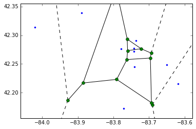

```python
voronoi_plot_2d(vor)
plt.show()
```

Alternatively, we can use the matplotlib `fill` method.

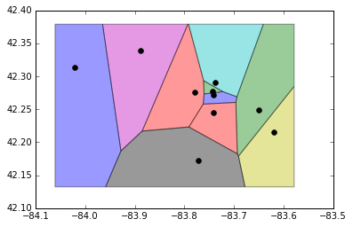

```python
[plt.fill(*zip(*poly.exterior.coords), alpha=0.4) for poly in R]
plt.plot(x, y, 'ko')
plt.show()
```

### Bokeh

```python
from bokeh.io import output_file, show
from bokeh.models import GMapPlot, GMapOptions, ColumnDataSource, DataRange1d
from bokeh.models import Circle, Patch, PanTool, ResetTool, WheelZoomTool, ResizeTool
from bokeh import palettes

# Set map options
map_options = GMapOptions(lng=-83.8, lat=42.25, zoom=11, map_type="roadmap")

# set up google map plot
plot = GMapPlot(plot_height = 800, plot_width = 1000,
                x_range=DataRange1d(), y_range=DataRange1d(),
                map_options=map_options, api_key=apikey)

# remove 'ugly' borders
plot.min_border_bottom = 0
plot.min_border_top = 0
plot.min_border_left = 0
plot.min_border_right = 0

# choose colour palette
colours = palettes.Spectral11

# iterate through each polygon and add to plot as a patch glyph
for n, poly in enumerate(R):
    df = pd.DataFrame(list(poly.exterior.coords), columns=['lon','lat'])
    source = ColumnDataSource(df)
    glyph = Patch(x="lon",y="lat", fill_alpha=0.3, fill_color=colours[n], line_color="red", line_width=1)
    plot.add_glyph(source, glyph)

# add each point to plot as a circle glyph
source = ColumnDataSource(dict(lat=y,lon=x))
circle = Circle(x="lon", y="lat", size=15, fill_color="blue", fill_alpha=0.4, line_color=None)
plot.add_glyph(source, circle)

# add interactive tools
plot.add_tools(PanTool(), ResetTool(), WheelZoomTool(), ResizeTool())

# plot figures
output_file('voronoi.html','Cottage Inn Pizza')
show(plot)
```

[interactive chart not shown]

### Step 4

We'll be using the `simplekml` module to write to a KML file. We could have used `BeautifulSoup` but I feel its more cumbersome to use since you have to write all the tags yourself.

```python
import simplekml
from bokeh import palettes
```

Setup color palette and transparency

```python
colours = palettes.Spectral11
colours = ['7f'+c[1:] for c in colours] # kml color format is 'AARRGGBB'
```

Create an instance of the simplekml.Kml class and iterate through each polygon assigning name, coordinates, and styling.

```python
cvs = simplekml.Kml()
for i, poly in enumerate(R, start=1):
    area = cvs.newpolygon(name='Cottage Inn Area',
                           outerboundaryis=list(poly.exterior.coords))
    area.style.polystyle.color = colours[i]
    area.style.linestyle.color = "black"
    area.style.linestyle.width = 1
```

Save instance to a file

```python
cvs.save(r'data\voronoi_polygons.kml')
```

### Google Maps

Then you can import the KML file into Google Maps. [SHORT INTERLUDE]

## Software Version for Creating this Jupyter Notebook

```python
# you only need to do the following line once on your machine
#%install_ext http://raw.github.com/jrjohansson/version_information/master/version_information.py
%load_ext version_information
```

```python
%version_information fiona, shapely, rtree, geopandas, pandas, geocoder, requests, bokeh, matplotlib, numpy, bs4, scipy, more_itertools, geojson, simplekml
```

| Software | Version |
| --- | --- |
| Python | 3.5.1 64bit [MSC v.1900 64 bit (AMD64)] |
| IPython | 4.1.2 |
| OS | Windows 7 6.1.7601 SP1 |
| fiona | 1.7.0 |
| shapely | 1.5.16 |
| rtree | 0.8.2 |
| geopandas | 0.2.1 |
| pandas | 0.18.1 |
| geocoder | 1.17.4 |
| requests | 2.11.1 |
| bokeh | 0.12.3 |
| matplotlib | 1.5.1 |
| numpy | 1.10.4 |
| bs4 | 4.4.1 |
| scipy | 0.17.0 |
| more_itertools | 2.2 |
| geojson | 1.3.3 |
| simplekml | 1.2.8 |
| Thu Nov 03 11:29:38 2016 Eastern Daylight Time |  |